# Boston Crime Analysis and Prediction

Boston Crime Analysis and Prediction

Code Explanation

Web application and API Web Scraping

Analysis

Data Preprocessing Data Analysis Regression Analysis Markov Chain Analysis Shortest Patrol Route Analysis

Demo

Markov Chain Regression API Crime Forecast

# **Boston Crime** Markov Chain Analysis

## Pattern analysis using Markov Chain

Markov chain is a model used for describing a sequence of possible events that depends on a previous event. We will give an example with our analysis.  
We can use the Markov chain to create to nodes of districts and probabilities that the state will move to the next node (crime happen on the next district)

For more insightful analysis, we will create a Markov chain for groups of crime, instead of overall crime.

- Load csv file and print group of crimes

```python
import pandas as pd

crimeandweather = pd.read_csv('../data/crimeandweather.csv')
crimeandweather['OFFENSE_CODE_GROUP'].unique()
```

```
array([nan, 'Auto Theft', 'Investigate Property', 'Investigate Person',
       'Verbal Disputes', 'Vandalism', 'Motor Vehicle Accident Response',
       'Aggravated Assault', 'Residential Burglary', 'Larceny',
       'Firearm Violations', 'Medical Assistance', 'Simple Assault',
       'Missing Person Reported', 'Robbery', 'Property Lost',
       'Violations', 'Firearm Discovery', 'Warrant Arrests', 'Other',
       'Ballistics', 'Towed', 'Drug Violation', 'Fire Related Reports',
       'Fraud', 'Disorderly Conduct', 'Police Service Incidents',
       'Larceny From Motor Vehicle', 'Missing Person Located',
       'Harassment', 'Property Found', 'Liquor Violation',
       'Property Related Damage', 'Confidence Games',
       'Commercial Burglary', 'Recovered Stolen Property',
       'Other Burglary', 'Assembly or Gathering Violations',
       'Counterfeiting', 'Prisoner Related Incidents',
       'License Plate Related Incidents', 'Restraining Order Violations',
       'Search Warrants', 'License Violation', 'Landlord/Tenant Disputes',
       'Auto Theft Recovery', 'Operating Under the Influence',
       'Evading Fare', 'Embezzlement', 'Criminal Harassment',
       'Harbor Related Incidents', 'Service',
       'Offenses Against Child / Family', 'Prostitution', 'Homicide',
       'Biological Threat', 'Explosives', 'Arson', 'Aircraft',
       'HUMAN TRAFFICKING - INVOLUNTARY SERVITUDE', 'HOME INVASION',
       'Phone Call Complaints', 'Bomb Hoax', 'Manslaughter',
       'HUMAN TRAFFICKING', 'Gambling', 'INVESTIGATE PERSON',
       'Burglary - No Property Taken'], dtype=object)
```

To illustrate the Markov chain, we will work with small data first.  
We decide to use bank robbery crime which is a subgroup of robbery

- Create Morkov chain function  
  We will use these code a lot

```python
def Markov_chain_analysis(t, des):
    if t == 'description':
        t = 'OFFENSE_DESCRIPTION'
    else:
        t = 'OFFENSE_CODE_GROUP'

    # get dataframe
    crime = crimeandweather[crimeandweather[t] == des]
    crime.index = pd.to_datetime(crime['OCCURRED_ON_DATE'])
    crime = crime.sort_index(axis = 0)
    # create list of dic for count
    districtdict = {}
    uniquedistrictlist = crime['DISTRICT'].unique().tolist()
    for i in uniquedistrictlist:
        districtdict[i] = []

    # add next district to current district
    alldistrictlist = crime['DISTRICT'].tolist()
    for i in range(0,len(alldistrictlist)-1):
        districtdict[alldistrictlist[i]].append(alldistrictlist[i+1])

    # count duplicate in list and sum for cal prob
    countdistrictdict = {}
    for i in districtdict.keys():
        countdistrictdict[i] = {}
        countdistrictdict[i]['sum'] = 0
        for j in districtdict[i]:
            if j in countdistrictdict[i].keys():
                countdistrictdict[i][j] += 1
            else :
                countdistrictdict[i][j] = 1
            countdistrictdict[i]['sum'] += 1

    # change count them to prob
    probdistrictdict = {}
    for i in countdistrictdict.keys():
        probdistrictdict[i] = {}
        for j in countdistrictdict[i].keys():
            if countdistrictdict[i]['sum'] == 0:
                probdistrictdict[i][j] = 0
            else:
                probdistrictdict[i][j] =  round(countdistrictdict[i][j]/countdistrictdict[i]['sum'],4)
        probdistrictdict[i].pop('sum')

    return probdistrictdict
```

What this function does is it goes through specific crime records and counts the next districts. For example, if the first bank robbery happens in A1, and the next one is in B2. For A1 node, the value of B2 is 1. If the next crime happen in C11, A1 node has 1 B2, and B2 node has 1 C11. The process repeats until it reaches the end. Then it will calculate the probability of the next node. For instead, start with A1, there is 5 B2 and 5 C11, so the probability that the bank robbery happened in B2 after A1 is 0.5

- Create a dictionary of probebilities of bank robbery and plot the result

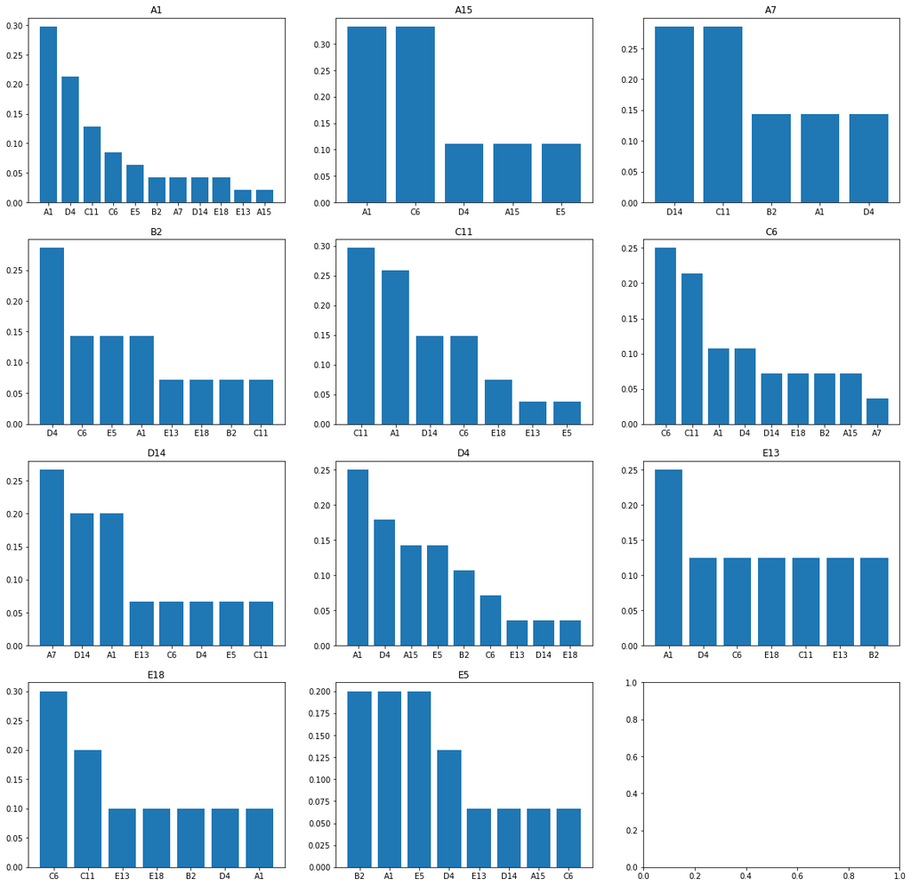

```python
bankrobcrime = Markov_chain_analysis('description', 'ROBBERY - BANK')

import matplotlib.pyplot as plt
%matplotlib inline

# plot prob
cols = 3
rows = 4
fig, ax = plt.subplots(4, 3, figsize=(20,20))
key = list(sorted(bankrobcrime))
n = 0
for i in range(0, rows):
    for j in range(0, cols):
        if i == 3 and j == 2:
            break
        index = j + i-1
        lists = sorted(bankrobcrime[key[n]].items(), key = lambda x : x[1], reverse=True)
        x, y = zip(*lists)
        ax[i, j].bar(x, y)
        ax[i, j].set_title(key[n])
        n += 1
```

We can see from the bar graph that in if the bank robbery happens in E18 district, the probability of the next bank robbery happens in C6 district is 0.3

However, this model is not always valid.  
There is a limitation of the model which depend on sample size and the probability of the event. We will not go into detail how to check the validity of the model. But, when we use the model with the large sample size, the model is mostly valid.

Let look into the drug violation and analyze the pattern of it.

- List all type of drug violation

```python
crimeandweather[crimeandweather['OFFENSE_CODE_GROUP'] == 'Drug Violation']['OFFENSE_DESCRIPTION'].unique()
```

```
array(['DRUGS - POSS CLASS B - INTENT TO MFR DIST DISP',
       'DRUGS - POSS CLASS B - COCAINE, ETC.', 'DRUGS - OTHER',
       'DRUGS - POSS CLASS D - INTENT TO MFR DIST DISP',
       'DRUGS - SICK ASSIST - HEROIN',
       'DRUGS - POSS CLASS A - HEROIN, ETC. ',
       'DRUGS - POSS CLASS A - INTENT TO MFR DIST DISP',
       'DRUGS - SALE / MANUFACTURING',
       'DRUGS - POSS CLASS C - INTENT TO MFR DIST DISP',
       'DRUGS - CLASS B TRAFFICKING OVER 18 GRAMS',
       'DRUGS - SICK ASSIST - OTHER NARCOTIC', 'DRUGS - POSS CLASS D',
       'DRUGS - CLASS A TRAFFICKING OVER 18 GRAMS',
       'DRUGS - CLASS D TRAFFICKING OVER 50 GRAMS',
       'DRUGS - POSS CLASS E', 'DRUGS - POSS CLASS C',
       'DRUGS - SICK ASSIST - OTHER HARMFUL DRUG',
       'DRUGS - CONSP TO VIOL CONTROLLED SUBSTANCE',
       'DRUGS - POSS CLASS E - INTENT TO MFR DIST DISP',
       'DRUGS - POSSESSION OF DRUG PARAPHANALIA', 'DRUGS - POSSESSION',
       'CONSPIRACY EXCEPT DRUG LAW', 'DRUGS - GLUE INHALATION',
       'DRUGS - POSS CLASS A - HEROIN, ETC.',
       'DRUGS - POSS CLASS D - MARIJUANA, ETC.',
       'DRUGS - POSS CLASS E INTENT TO MF DIST DISP',
       'DRUGS - POSS CLASS D - INTENT MFR DIST DISP'], dtype=object)
```

The data cover many types of drug violations, and we will use all of these for our analysis

- Create a dictionary of probabilities of drug violation and plot the result

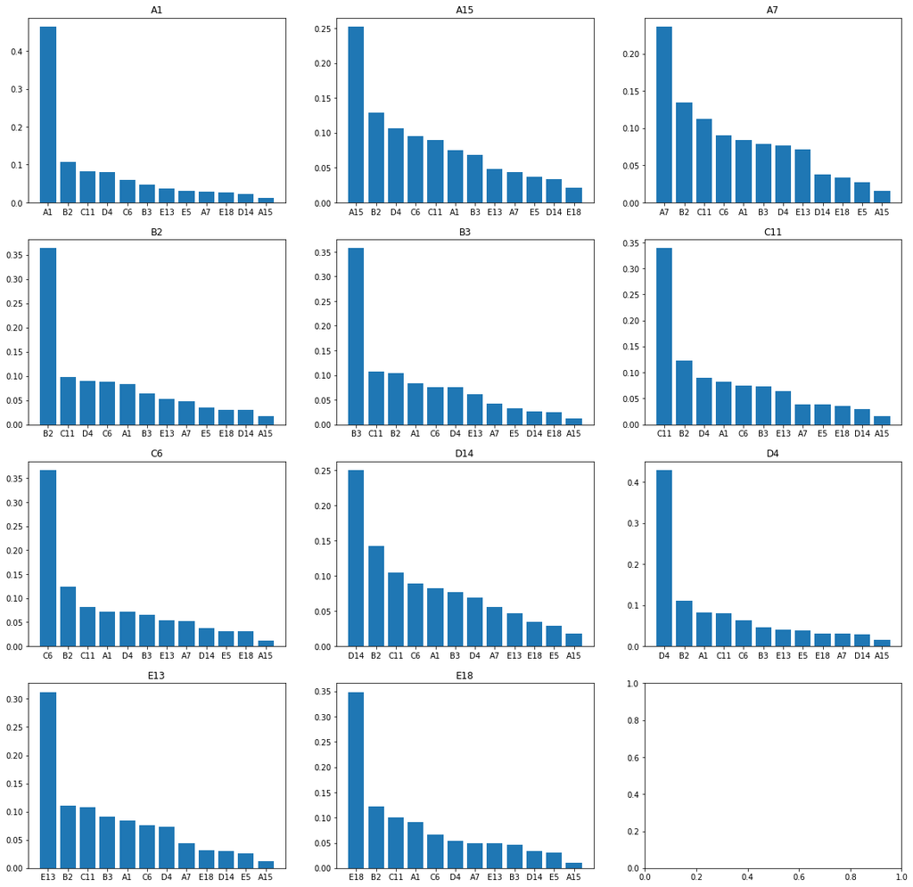

```python
drugcrime = Markov_chain_analysis('group', 'Drug Violation')

# plot prob
cols = 3
rows = 4
fig, ax = plt.subplots(4, 3, figsize=(20,20))
key = list(sorted(drugcrime))
n = 0
for i in range(0, rows):
    for j in range(0, cols):
        if i == 3 and j == 2:
            break
        index = j + i-1
        lists = sorted(drugcrime[key[n]].items(), key = lambda x : x[1], reverse=True)
        x, y = zip(*lists)
        ax[i, j].bar(x, y)
        ax[i, j].set_title(key[n])
        n += 1
```

We can clearly see the pattern of the drug violation.  
If the crime occurs in one district, it more likely to happens in the same district for a while before it goes to the next district.  
The B2 and C11 probability are high compared with other districts in all nodes.

We have a hypothesis that the drug violation relates to auto theft because drug dealers need a vehicle to transport drugs, and they will not buy it from the car dealer. Let's analyze the auto theft pattern.

- Create a dictionary of probabilities of auto theft and plot the result

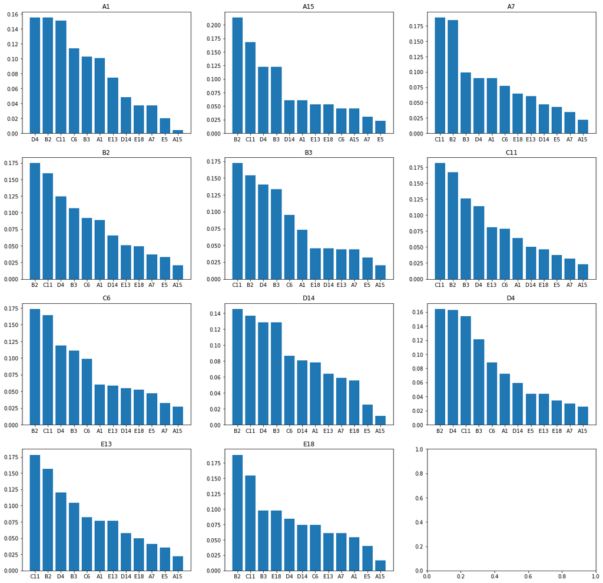

```python
autocrime = Markov_chain_analysis('group', 'Auto Theft')

# plot prob
cols = 3
rows = 4
fig, ax = plt.subplots(4, 3, figsize=(20,20))
key = list(sorted(autocrime))
n = 0
for i in range(0, rows):
    for j in range(0, cols):
        if i == 3 and j == 2:
            break
        index = j + i-1
        lists = sorted(autocrime[key[n]].items(), key = lambda x : x[1], reverse=True)
        x, y = zip(*lists)
        ax[i, j].bar(x, y)
        ax[i, j].set_title(key[n])
        n += 1
```

Unfortunately, the pattern is not the same as drug violation.  
However, the B2 and C11 districts have more probability than the other districts in all nodes.  
The probability of B2 and C11 is high in all node in drug violation too.

We can use this model to calculate the probability given we know the current node.

Next: Markov Chain Demo Next: Regression Analysis